# IS 4487 Assignment 6: Data Cleaning with Airbnb Listings

In this assignment, you will:

- Load a raw Airbnb listings dataset
- Identify and resolve missing or inconsistent data
- Decide what data to drop, keep, or clean
- Save a clean dataset to use in Assignment 7

## Why This Matters

Data cleaning is one of the most important steps in any analysis — but it's often the least visible. Airbnb hosts, managers, and policy teams rely on clean data to make decisions. This assignment gives you experience cleaning raw data and justifying your choices so others can understand your process.

## Dataset Description

The dataset you'll be using is a **detailed Airbnb listing file**, available from [Inside Airbnb](https://insideairbnb.com/get-the-data/).

Each row represents one property listing. The columns include:

- **Host attributes** (e.g., host ID, host name, host response time)
- **Listing details** (e.g., price, room type, minimum nights, availability)
- **Location data** (e.g., neighborhood, latitude/longitude)
- **Property characteristics** (e.g., number of bedrooms, amenities, accommodates)
- **Calendar/booking variables** (e.g., last review date, number of reviews)

📌 The schema is consistent across cities, so you can expect similar columns regardless of the location you choose.

## 1. Choose a City & Upload Your Dataset

📥 Follow these steps:

1. Go to: https://insideairbnb.com/get-the-data/
2. Choose a city you’re interested in.
3. Download the file named: **`listings.csv.gz`** under that city.
4. In your notebook:
   - Open the left sidebar
   - Click the folder icon 📁
   - Click the upload icon ⬆️ and choose your `listings.csv.gz` file
5. Use the file path `/content/listings.csv.gz` when loading your data.
6. Import standard libraries (`pandas`, `numpy`, `seaborn`, `matplotlib`)

```python
# Import necessary libraries 🔧
import pandas as pd
import numpy as np
import seaborn as sns
import matplotlib.pyplot as plt
```

```python
# Load your uploaded file (path "/content/listings.csv.gz") 🔧
file_path = "/content/listings.csv.gz"
df = pd.read_csv(file_path, compression='gzip')
```

```python
df.head()
```

|  | id | listing_url | scrape_id | last_scraped | source | name | description | neighborhood_overview | picture_url | host_id | ... | review_scores_communication | review_scores_location | review_scores_value | license | instant_bookable | calculated_host_listings_count | calculated_host_listings_count_entire_homes | calculated_host_listings_count_private_rooms | calculated_host_listings_count_shared_rooms | reviews_per_month |
| --- | --- | --- | --- | --- | --- | --- | --- | --- | --- | --- | --- | --- | --- | --- | --- | --- | --- | --- | --- | --- | --- |
| 0 | 27886 | https://www.airbnb.com/rooms/27886 | 20250911031321 | 2025-09-11 | city scrape | Romantic, stylish B&B houseboat in canal district | Stylish and romantic houseboat on fantastic hi... | Central, quiet, safe, clean and beautiful. | https://a0.muscache.com/pictures/02c2da9d-660e... | 97647 | ... | 4.93 | 4.90 | 4.78 | 0363 974D 4986 7411 88D8 | f | 1 | 0 | 1 | 0 | 1.87 |
| 1 | 28871 | https://www.airbnb.com/rooms/28871 | 20250911031321 | 2025-09-11 | city scrape | Comfortable double room | Basic bedroom in the center of Amsterdam. | Flower market , Leidseplein , Rembrantsplein | https://a0.muscache.com/pictures/160889/362340... | 124245 | ... | 4.94 | 4.93 | 4.83 | 0363 607B EA74 0BD8 2F6F | f | 2 | 0 | 2 | 0 | 3.99 |
| 2 | 29051 | https://www.airbnb.com/rooms/29051 | 20250911031321 | 2025-09-11 | city scrape | Comfortable single / double room | This room can also be rented as a single or a ... | the street is quite lively especially on weeke... | https://a0.muscache.com/pictures/162009/bd6be2... | 124245 | ... | 4.92 | 4.87 | 4.79 | 0363 607B EA74 0BD8 2F6F | f | 2 | 0 | 2 | 0 | 4.81 |
| 3 | 44391 | https://www.airbnb.com/rooms/44391 | 20250911031321 | 2025-09-11 | previous scrape | Quiet 2-bedroom Amsterdam city centre apartment | Guests greatly appreciate the unique location ... | The appartment is located in the city centre. ... | https://a0.muscache.com/pictures/97741545/3900... | 194779 | ... | 4.90 | 4.68 | 4.50 | 0363 E76E F06A C1DD 172C | f | 1 | 1 | 0 | 0 | 0.23 |
| 4 | 48373 | https://www.airbnb.com/rooms/48373 | 20250911031321 | 2025-09-11 | previous scrape | Cozy family home in Amsterdam South | Charming modern apartment in the quiet and gre... | Apartment is located between Amsterdamse Bos a... | https://a0.muscache.com/pictures/miso/Hosting-... | 220434 | ... | 5.00 | 4.60 | 5.00 | 0363 4A2B A6AD 0196 F684 | f | 1 | 1 | 0 | 0 | 0.19 |

5 rows × 79 columns

## 2. Explore Missing Values

### Business framing:

Stakeholders don’t like surprises in the data. Missing values can break dashboards, confuse pricing models, or create blind spots for host managers.

### Do the following:

Explore how complete your dataset is:

- Count the null values of each column
- Create visuals (e.g. heatmaps, boxplots, bar charts, etc) to help show what columns are missing values
- Keep in mind which column(s) are missing too much data, you will delete these in the next step

### In your markdown:

1. What are the top 3 columns with the most missing values?
2. Which ones are likely to create business issues?
3. Which could be safely ignored or dropped?

```python
# Count Null Values
missing_counts = df.isnull().sum().sort_values(ascending=False)
missing_counts
```

|  | 0 |
| --- | --- |
| neighbourhood_group_cleansed | 10480 |
| calendar_updated | 10480 |
| host_neighbourhood | 7690 |
| neighbourhood | 5288 |
| neighborhood_overview | 5288 |
| ... | ... |
| instant_bookable | 0 |
| calculated_host_listings_count | 0 |
| calculated_host_listings_count_entire_homes | 0 |
| calculated_host_listings_count_private_rooms | 0 |
| calculated_host_listings_count_shared_rooms | 0 |

79 rows × 1 columns

**dtype:** int64

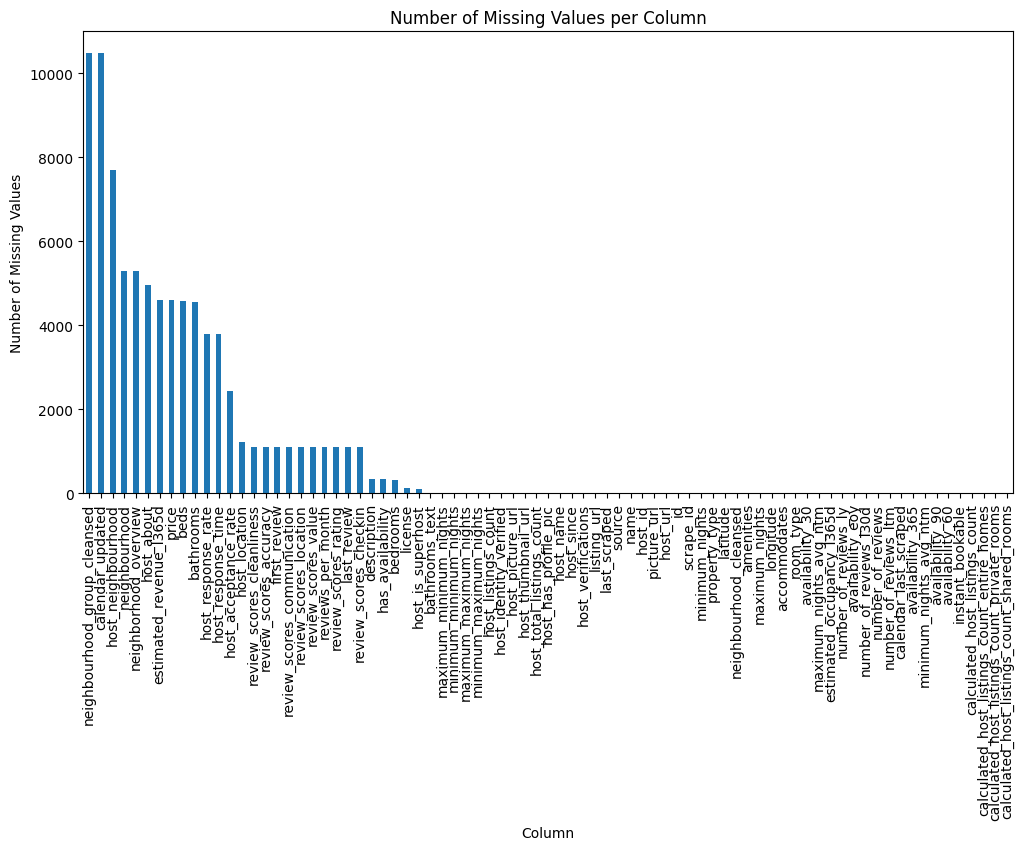

```python
# Visuals
missing_counts.plot(kind='bar', figsize=(12,6))
plt.title('Number of Missing Values per Column')
plt.xlabel('Column')
plt.ylabel('Number of Missing Values')
plt.show ()
```

### ✍️ Your Response: 🔧

1. neighbourhood_group_cleansed, calendar_updated, and host_neighbourhood
2. reviews_per_month and host_response_time are critical for pricing models and host performance dashboards.
3. Columns like host_about often have many missing entries but are not essential for basic analysis, so they could be dropped to simplify the dataset.

## 3. Drop Columns That Aren’t Useful

### Business framing:

Not every column adds value. Analysts often remove columns that are too empty, irrelevant, or repetitive — especially when preparing data for others.

### Do the following:

Make a decision:

- Choose 2–4 columns to drop from your dataset
- Document your reasons for each one
- Confirm they're gone with `.head()` or `.info()`

### In Your Response:

1. Which columns did you drop?
2. Why were they not useful from a business perspective?
3. What could go wrong if you left them in?

```python
columns_to_drop = ['license', 'host_about', 'neighbourhood_group_cleansed']
df = df.drop(columns=columns_to_drop)
df.head()
```

|  | id | listing_url | scrape_id | last_scraped | source | name | description | neighborhood_overview | picture_url | host_id | ... | review_scores_checkin | review_scores_communication | review_scores_location | review_scores_value | instant_bookable | calculated_host_listings_count | calculated_host_listings_count_entire_homes | calculated_host_listings_count_private_rooms | calculated_host_listings_count_shared_rooms | reviews_per_month |
| --- | --- | --- | --- | --- | --- | --- | --- | --- | --- | --- | --- | --- | --- | --- | --- | --- | --- | --- | --- | --- | --- |
| 0 | 27886 | https://www.airbnb.com/rooms/27886 | 20250911031321 | 2025-09-11 | city scrape | Romantic, stylish B&B houseboat in canal district | Stylish and romantic houseboat on fantastic hi... | Central, quiet, safe, clean and beautiful. | https://a0.muscache.com/pictures/02c2da9d-660e... | 97647 | ... | 4.95 | 4.93 | 4.90 | 4.78 | f | 1 | 0 | 1 | 0 | 1.87 |
| 1 | 28871 | https://www.airbnb.com/rooms/28871 | 20250911031321 | 2025-09-11 | city scrape | Comfortable double room | Basic bedroom in the center of Amsterdam. | Flower market , Leidseplein , Rembrantsplein | https://a0.muscache.com/pictures/160889/362340... | 124245 | ... | 4.94 | 4.94 | 4.93 | 4.83 | f | 2 | 0 | 2 | 0 | 3.99 |
| 2 | 29051 | https://www.airbnb.com/rooms/29051 | 20250911031321 | 2025-09-11 | city scrape | Comfortable single / double room | This room can also be rented as a single or a ... | the street is quite lively especially on weeke... | https://a0.muscache.com/pictures/162009/bd6be2... | 124245 | ... | 4.93 | 4.92 | 4.87 | 4.79 | f | 2 | 0 | 2 | 0 | 4.81 |
| 3 | 44391 | https://www.airbnb.com/rooms/44391 | 20250911031321 | 2025-09-11 | previous scrape | Quiet 2-bedroom Amsterdam city centre apartment | Guests greatly appreciate the unique location ... | The appartment is located in the city centre. ... | https://a0.muscache.com/pictures/97741545/3900... | 194779 | ... | 4.95 | 4.90 | 4.68 | 4.50 | f | 1 | 1 | 0 | 0 | 0.23 |
| 4 | 48373 | https://www.airbnb.com/rooms/48373 | 20250911031321 | 2025-09-11 | previous scrape | Cozy family home in Amsterdam South | Charming modern apartment in the quiet and gre... | Apartment is located between Amsterdamse Bos a... | https://a0.muscache.com/pictures/miso/Hosting-... | 220434 | ... | 5.00 | 5.00 | 4.60 | 5.00 | f | 1 | 1 | 0 | 0 | 0.19 |

5 rows × 76 columns

## 4. Fill or Fix Values in Key Columns

### Business framing:

Let’s say your manager wants to see a map of listings with prices and review scores. If key fields are blank, the map won’t work. But not all missing values should be filled the same way.

### Do the following:

- Choose 2 columns with missing values
- Use a strategy to fill or flag those values
  - (e.g., median, “unknown”, forward-fill, or a placeholder)
- Explain what you did and why

### In your response:

1. What two columns did you clean?
2. What method did you use for each, and why?
3. What risks are there in how you filled the data?

```python
print(f"Missing bedrooms before: {df['bedrooms'].isnull().sum()}")

df['bedrooms'] = df.groupby('room_type')['bedrooms'].transform(lambda x: x.fillna(x.median()))
df['bedrooms'] = df['bedrooms'].fillna(df['bedrooms'].median())

print(f"Missing bedrooms after: {df['bedrooms'].isnull().sum()}")
```

[output not shown]

```python
print(f"Missing reviews_per_month before: {df['reviews_per_month'].isnull().sum()}")

df['reviews_per_month'] = df['reviews_per_month'].fillna(0)

print(f"Missing reviews_per_month after: {df['reviews_per_month'].isnull().sum()}")
```

[output not shown]

### ✍️ Your Response: 🔧

1. bedrooms and reviews_per_month
2. I filled missing bedrooms with the median for each room type, since whole homes usually have more bedrooms than private rooms. Missing reviews_per_month were filled with 0 to show no review activity.
3. Filling bedrooms with the median hides unusual cases, like very small or large properties, which can distort pricing and capacity estimates. Filling reviews with zero mixes new, inactive, or missing listings, making some appear worse than they are. Both methods make the data simpler but can misrepresent reality.

## 5. Convert and Clean Data Types

### Business framing:

Sometimes columns that look like numbers are actually stored as text — which breaks calculations and slows down analysis. Common examples are price columns with dollar signs or availability stored as strings.

### Do the following:

- Identify one column with the wrong data type
- Clean and convert it into a usable format (e.g., from string to number)
- Check your work by summarizing or plotting the cleaned column

### In Your Response: :

1. What column did you fix?
2. What cleaning steps did you apply?
3. How does this help prepare the data for later use?

```python
print("Original price column:")
print(df['price'].head(10))
print(f"\nData type: {df['price'].dtype}")
```

```
Original price column:
0    $132.00
1     $89.00
2     $61.00
3        NaN
4        NaN
5    $322.00
6    $457.00
7    $198.00
8    $162.00
9        NaN
Name: price, dtype: object

Data type: object
```

```python
df['price_cleaned'] = df['price'].replace(r'[\$,]', '', regex=True).astype(float)

print("\nCleaned price column:")
print(df['price_cleaned'].head(10))
print(f"\nData type: {df['price_cleaned'].dtype}")
print(f"\nBasic statistics:\n{df['price_cleaned'].describe()}")
```

```
Cleaned price column:
0    132.0
1     89.0
2     61.0
3      NaN
4      NaN
5    322.0
6    457.0
7    198.0
8    162.0
9      NaN
Name: price_cleaned, dtype: float64

Data type: float64

Basic statistics:
count     5874.000000
mean       336.785155
std       1985.661882
min         35.000000
25%        161.000000
50%        222.000000
75%        314.000000
max      80018.000000
Name: price_cleaned, dtype: float64
```

[figure not shown]

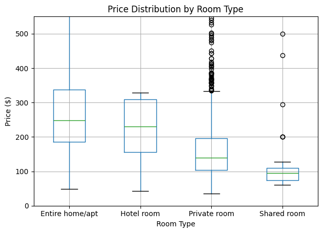

```python
# Visualize cleaned price data
plt.figure(figsize=(12, 5))

plt.subplot(1, 2, 1)
plt.hist(df['price_cleaned'].dropna(), bins=50, edgecolor='black', alpha=0.7)
plt.xlabel('Price ($)')
plt.ylabel('Frequency')
plt.title('Distribution of Listing Prices')
plt.xlim(0, df['price_cleaned'].quantile(0.95))

plt.subplot(1, 2, 2)
df.boxplot(column='price_cleaned', by='room_type')
plt.xlabel('Room Type')
plt.ylabel('Price ($)')
plt.title('Price Distribution by Room Type')
plt.suptitle('')
plt.ylim(0, df['price_cleaned'].quantile(0.95))

plt.tight_layout()
plt.show()
```

### ✍️ Your Response: 🔧

1. I cleaned the price column, which was originally stored as a string/object type instead of numeric. This column is critical for analyses like pricing models, revenue calculations, and comparisons across listings.
2. I used a regex to remove dollar signs and commas, then converted the cleaned strings to float using .astype(float). This ensures the values are in a numeric format that Python can use for calculations.
3. Converting price to numeric allows accurate calculations, filtering, sorting, and visualizations. It enables tasks like computing average prices, building pricing prediction models, and analyzing host performance operations that would fail or be incorrect if price remained a string.

## 6. Remove Duplicate Records

### Business framing:

If a listing appears twice, it could inflate revenue estimates or confuse users. Airbnb needs each listing to be unique and accurate.

### Do the following:

- Check for rows that are exact duplicates
- If your data has an ID column and each ID is supposed to unique, then make sure there are no duplicate IDs
- Remove duplicates if found

### In your markdown:

1. Did you find duplicates?
2. How did you decide what to drop or keep?
3. Why are duplicates risky for Airbnb teams?

```python
print(f"Total rows: {len(df)}")
print(f"Exact duplicate rows: {df.duplicated().sum()}")

print(f"Unique listing IDs: {df['id'].nunique()}")
print(f"Duplicate IDs: {df['id'].duplicated().sum()}")

df = df.drop_duplicates(subset=['id'], keep='first')

print(f"\nAfter removing duplicates:")
print(f"Total rows: {len(df)}")
print(f"Duplicate IDs: {df['id'].duplicated().sum()}")
```

```
Total rows: 10480
Exact duplicate rows: 0
Unique listing IDs: 10480
Duplicate IDs: 0

After removing duplicates:
Total rows: 10480
Duplicate IDs: 0
```

### ✍️ Your Response: 🔧 🔧

1. No. Each listing had a unique ID, indicating the data was already cleaned by Inside Airbnb to show only one record per listing.
2. I used the drop_duplicates() method on the id column with keep='first' to ensure each listing appears only once. If duplicates existed, this would keep the first occurrence and remove subsequent ones.
3. Duplicates inflate metrics like total revenue and average occupancy by counting the same listing multiple times. They also cause listings to appear multiple times in search results and on maps, confusing customers and making it appear there are more properties available than actually exist.

## 7. Export Cleaned Data

Before wrapping up, export your cleaned Airbnb dataset to a CSV file. You'll need this file for **Assignment 7**, where you'll perform data transformation techniques.

### Do the following:

Make sure your data has:

- Cleaned and consistent column values
- Proper data types for each column
- Any unnecessary columns removed

This file should be the version of your dataset that you’d feel confident sharing with a teammate or using for deeper analysis.

```
# Explanation:
# - "cleaned_airbnb_data_6.csv" is the name of the file that will be saved
# - index=False prevents pandas from writing row numbers into the CSV
# - The file will be saved to your working directory (in Colab, you'll need to download it manually. Once you see the data in your files tab, just click on the three dots, then click “download”)
# - YOU MAY NEED TO PRESS “RUN” MULTIPLE TIMES IN ORDER FOR IT TO SHOW UP
# - FOR SOME DEVICES, IT MAY TAKE A FEW MINUTES BEFORE YOUR FILE SHOWS UP
```

```python
# export csv here 🔧
df.to_csv('cleaned_airbnb_data_6.csv', index=False)

print("File exported successfully")
print(f"Rows exported: {len(df)}")
print(f"Columns exported: {len(df.columns)}")
```

```
File exported successfully
Rows exported: 10480
Columns exported: 77
```

## 8. Final Reflection

You’ve just cleaned a real-world Airbnb dataset — the kind of work that happens every day in analyst and data science roles.

Before you move on to data transformation in Assignment 7, take a few moments to reflect on the decisions you made and what you learned.

### In your markdown:

1. What was the most surprising or challenging part of cleaning this dataset?
2. How did you decide which data to drop, fix, or keep?
3. What’s one way a business team (e.g., hosts, pricing analysts, platform ops) might benefit from the cleaned version of this data?
4. If you had more time, what would you explore or clean further?
5. How does this relate to your customized learning outcome you created in canvas?

Write your response clearly in full sentences. No more than a few sentences required per response.

### ✍️ Your Response: 🔧

1. I was surprised by how many important columns had missing data. The challenge was deciding when to fill missing values versus dropping columns, especially for fields like bedrooms where median fills could hide variation.
2. I focused on business value and completeness. Columns mostly empty or redundant were dropped. Critical columns like price and bedrooms were fixed using cleaning strategies, and reasonably complete, useful columns were kept.
3. Pricing analysts can now accurately calculate and compare prices, build models, and create dashboards. Cleaned bedroom and price data allow reliable insights for pricing recommendations.
4. I would handle outliers in price, create smarter imputations for missing reviews, and clean text fields like amenities to extract structured features for deeper analysis.
5. This taught me data preparation skills, such as, handling missing values, removing duplicates, and standardizing formats. I can apply these to nonprofit work by keeping donor and financial data clean, preventing duplicates, and preparing datasets for accurate analysis to support stewardship and program management.

## Submission Instructions

✅ Checklist:

- All code cells run without error
- All markdown responses are complete
- Submit on Canvas as instructed

```python
!jupyter nbconvert --to html "assignment_06_data_cleaning_MonbergTobin.ipynb"
```

```
[NbConvertApp] Converting notebook assignment_06_data_cleaning_MonbergTobin.ipynb to html
[NbConvertApp] WARNING | Alternative text is missing on 3 image(s).
[NbConvertApp] Writing 615133 bytes to assignment_06_data_cleaning_MonbergTobin.html
```